# QAQC.Comparisons

Alene Onion

October 2, 2018

## QAQC overview

The relevant section of the QAPP is II.4.A  
My understanding of these requirements is that we need to assess the following:

- Completeness: Did we collect all the samples we intended to
- Holding time exceedances
- Temperature upon receipt exceedances
- Equipment Blank exceedances (result > quantitation limit)
  - Step 1: identify a reporting limit based on the data collected in 2017+18
  - Step 2: pull EB values that exceed these reporting limits
  - Step 3: decide how to flag data associated with a failed blank
  - Step 4: with the remainin, acceptable data, perform data examinations (ex comparison to historic data) to detect outliers
- Precision
  - a.k.a. analysis of duplicate samples.
  - These must satisfy the precision criteria set forth in table 3 (screening) and table 4 (routine).
  - The QAPP requires that we analyze duplicates for nutrients, solids, turbidity, conductivity, hardness, metals, and minerals (see section II.5.A.a). This is everything excluding in situ parameters, alkalinity, DOC, and chlorophyll a
  - If the sample is a non detect, the duplicate is spiked and compared to the spike sample. For this reason we need to make sure the duplicate and spike bottles are collected separately.
- Accuracy
  - a.k.a. analysis of matrix spike samples and matrix spike duplicate samples
  - These must satisfy the accuracy criteria set forth in table 3 (screening) and table 4 (routine)
  - IMPORTANT – the QAPP only requires that we analyze spikes for nutrients, metals and minerals (see section II.5.A.b)! I’m presuming this excludes solids, turbidity, conductivity, and hardness in addition to in situ parameters, alkalinity, DOC, and chlorophyll a

## Equipment Blanks

Equipment blank fail: result > quantitation limit  
IT’S IMPORTANT TO NOTE: that the quantitation limit is NOT the reporting limit. It is set by the lab and can vary week to week. The reporting limit is the goal and the quantitation limit is what the lab actually achieved  
I separated these failures into those that are:

- 2Q: < 2 x the quantitation limit
- 3Q: < 3 x the quantitation limit
- 4Q: < 4 x the quantitation limit
- 5Q: < 5 x the quantitation limit
- Higher5Q: > 5 x the quantitation limit

Failures do not necessarily mean that we shouldn’t use the data. For one, the quantitation limit is determined by the lab and is not consistant. So instead of looking for “hits” we should be looking to see how much of the total sample the EB encompasses. For example:  
Ohio EPA (https://www.epa.ohio.gov/portals/35/documents/sw_samplingmanual.pdf) offers a table of recommended flags:

| Sample.Result | Interpretation |
| --- | --- |
| Sample <= 3x Blank | Reject sample results in this range as insufficiently different from blank results |
| 3x Blank < Sample <= 5x Blank | Likely indication that the analyte is present but poor confidence in the numerical result - generally limit data use to data “trend” applications |
| < 5x Blank < Sample <= 10x Blank | Consider the sample result to be an estimated concentration (qualified “J”) but still suitable for most data uses |
| < 10x Blank | Do not qualify data (blank contamination does not significantly change the result within the uncertainty of the value reported) |

Current strategy: I propose a two step process:  
1. Examine the failures to see if there are any field or lab errors that could explain them (with RoseAnn’s assistance)  
2. Identify all the samples that would be flagged according to the OHIO EPA table above

##### Failures per project

|  | project | 2Q | 3Q | 4Q | 5Q | Higher5Q | pass | percFAIL |
| --- | --- | --- | --- | --- | --- | --- | --- | --- |
| 2 | routine | 20 | 16 | 5 | 4 | 17 | 603 | 9.3 |
| 3 | screening | 6 | 6 | 2 | 4 | 14 | 313 | 9.3 |
| 1 | 2018 | 8 | 2 | 5 | 3 | 8 | 293 | 8.2 |
| 4 | wallkill | 1 | 0 | 1 | 2 | 0 | 68 | 5.6 |

##### Info from SDGs

Conclusions drawn from reading lab reports  
Only a few instances worth noting from lab reports

| project | sample_name | SDG | chemical_name | issue | Submitter |
| --- | --- | --- | --- | --- | --- |
| wallkill | 13MONH-0.4 EB_07192017_WS | R1706637 | TURBIDITY | Method 180.1 Turbidity: Due to a laboratory error, several samples were not analyzed within the 48 hour holding time. The data is flagged to indicate the holding time violation. | Emily Vail |
| routine | 04RAGA-1.4 EB_08152017_WS | R1707521 | Nitrate+Nitrite as Nitrogen | mislabeled (Gens 1.4) and out of temp | Donald Cardinal |
| routine | 04RAGA-1.4 EB_08152017_WS | R1707521 | Nitrogen, ammonia (As N) | mislabeled (Gens 1.4) and out of temp | Donald Cardinal |
| routine | 04RAGA-1.4 EB_08152017_WS | R1707521 | NITROGEN, KJELDAHL, TOTAL | mislabeled (Gens 1.4) and out of temp | Donald Cardinal |
| routine | 04RAGA-1.4 EB_08152017_WS | R1707521 | PHOSPHORUS, TOTAL (AS P) | mislabeled (Gens 1.4) and out of temp | Donald Cardinal |
| routine | 04RAGA-1.4 EB_08152017_WS | R1707521 | TURBIDITY | mislabeled (Gens 1.4) and out of temp | Donald Cardinal |
| routine | 04RAGA-1.4 EB_08152017_WS Diss | R1707521 | Carbon, Dissolved Organic (DOC) | mislabeled (Gens 1.4) and out of temp | Donald Cardinal |
| routine | 04RAGA-1.4 EB_08152017_WS Diss | R1707521 | Copper | mislabeled (Gens 1.4) and out of temp | Donald Cardinal |
| routine | 04RAGA-1.4 EB_08152017_WS Diss | R1707521 | Orthophosphate as Phosphorus, Dissolved | mislabeled (Gens 1.4) and out of temp | Donald Cardinal |
| routine | 04RAGA-1.4 EB_08152017_WS Diss | R1707521 | Zinc | mislabeled (Gens 1.4) and out of temp | Donald Cardinal |
| wallkill | 13WALK-29.9-EB_08022017_WS | R1707030 | Nitrate+Nitrite as Nitrogen | The MS recovery for Chlrodie and Nitrate/Nitrite could not be accurately determined as the amount present in the sample was greater than four times the amount added as spike. | Emily Vail |

##### Plotting Equipment blanks to understand underlying noise

I only plotted parameters which had failures in equipment blanks but included all the results (NA converted to 0) The horizontal line is at the quantitation limit (IT“S IMPORTANT TO NOTE: that the quantiation limit varies from week to week so it should not be considered a bar of succes)s  
The purpose of these plots is to see if there’s an underlying level of noise that we would consider acceptable and define as the new reporting limit

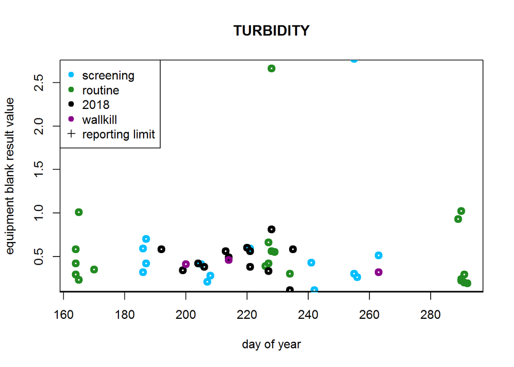

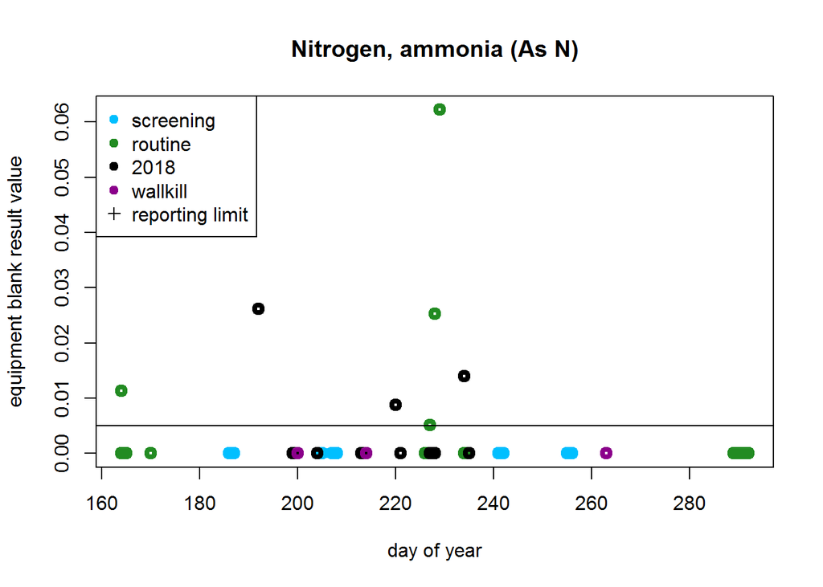

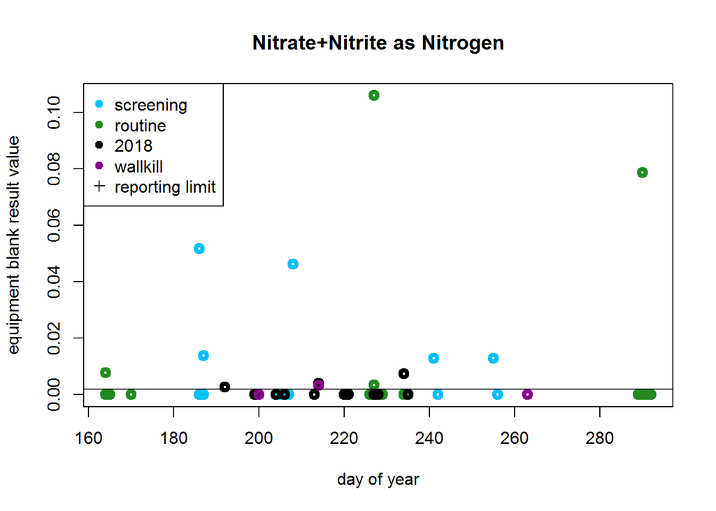

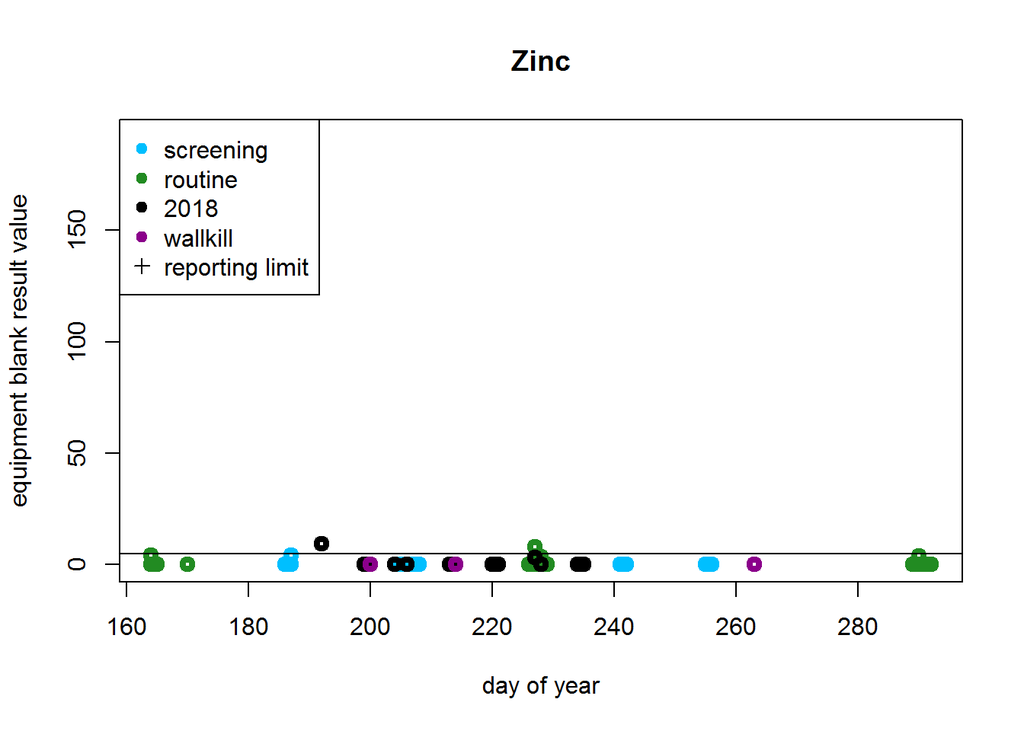

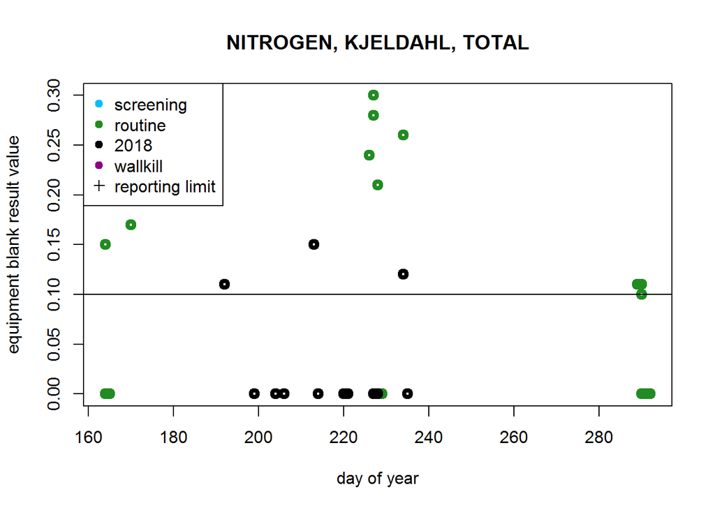

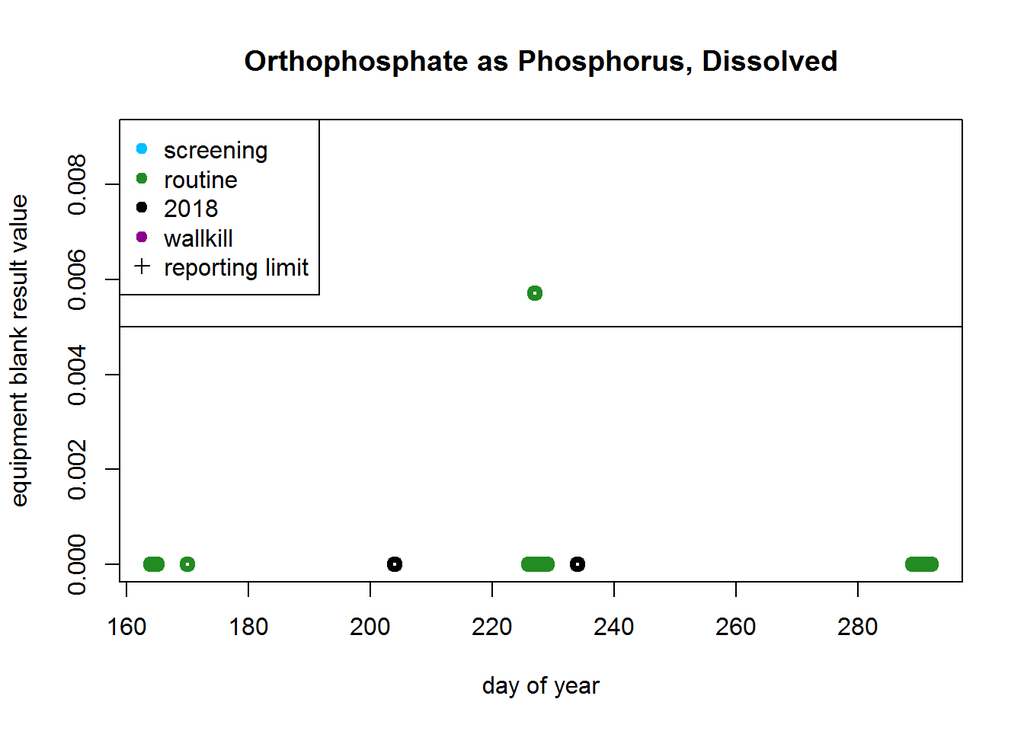

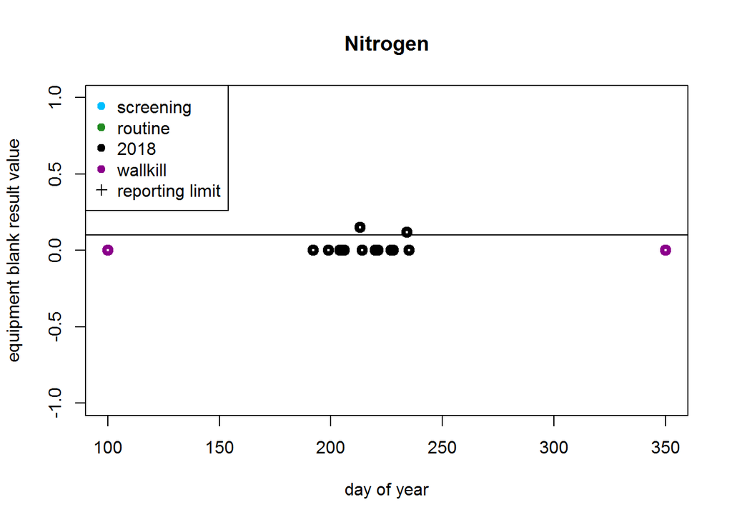

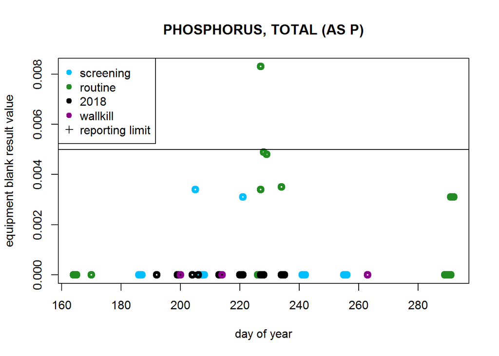

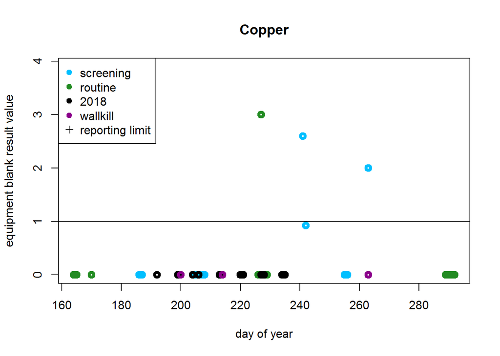

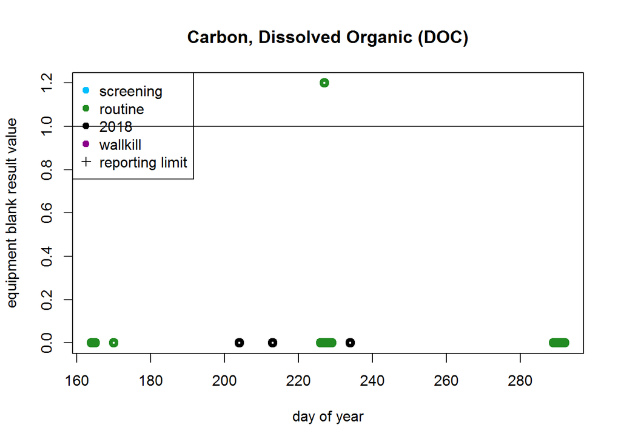

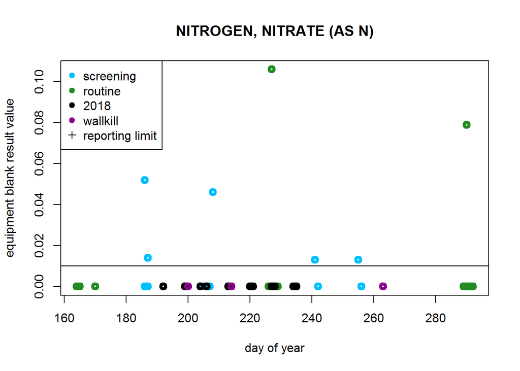

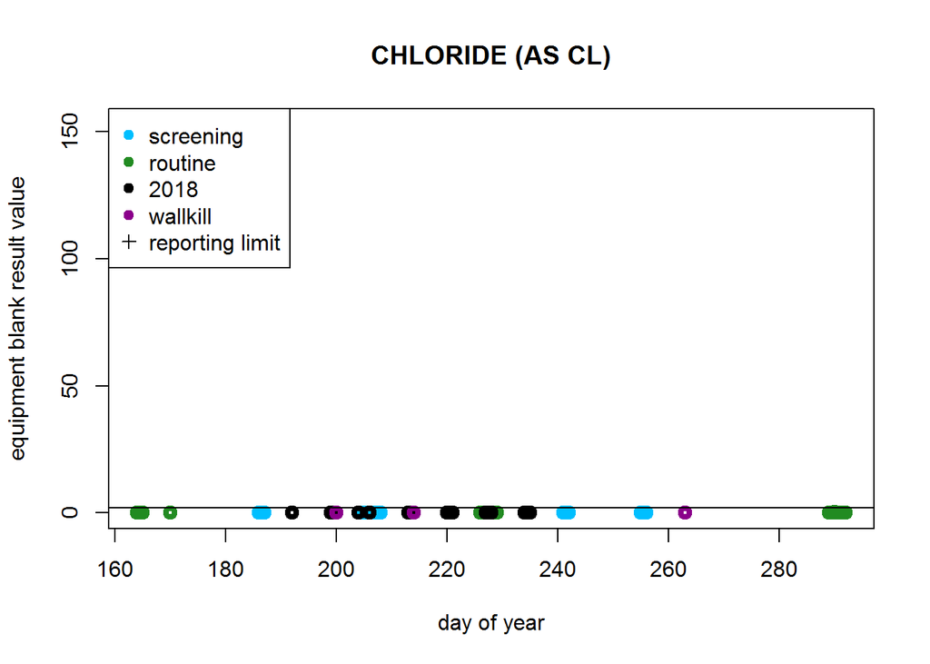

[4 more figures not shown]

##### comparing EB hits to the reuslt values

I calculated the percent the EB value makes up of the result value  
As a reminder, Ohio EPA rejects data which is less than 3x the equipment blank. Unfortunately, that means many of our nutrient readings would be rejected. I think this is a consquence, however, of very low readings: even a slight equipment blank reading would be a large percentage of a nutrient result since these results are so small to begin with.  
Scott Kishbaugh thought this might be a problem. I don’t currently have a sollution and am looking into it.  
only Routine and Wallkill done so far simply because that’s all I’ve been able to associate blanks to

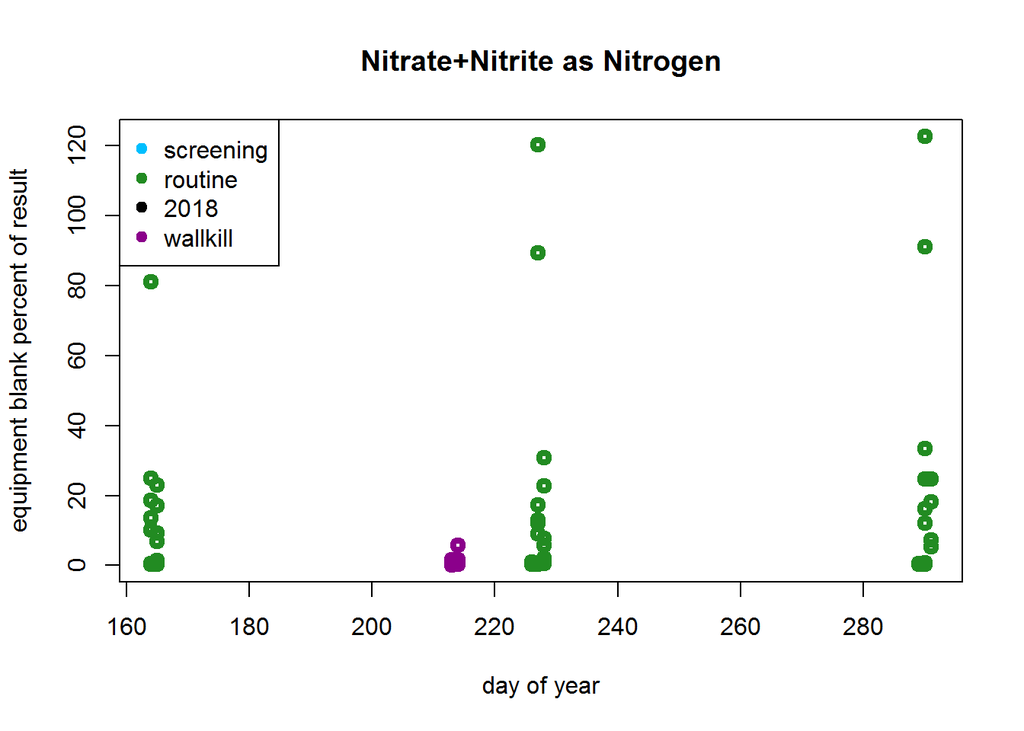

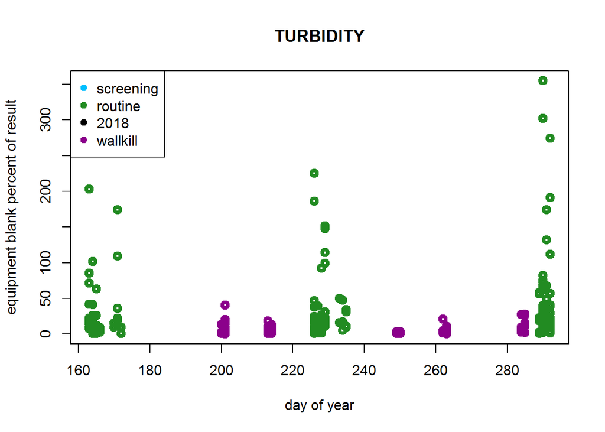

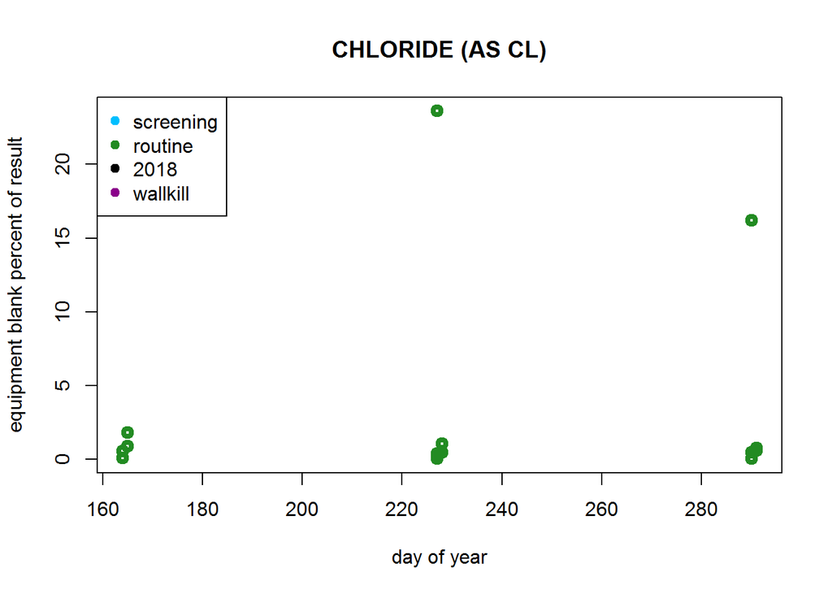

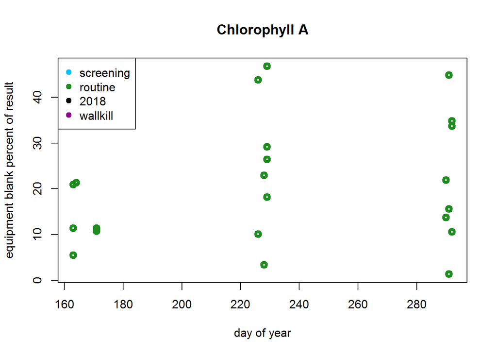

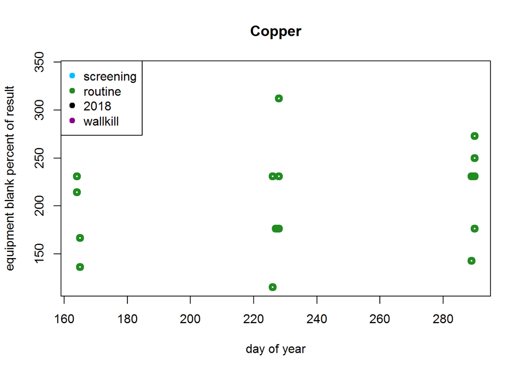

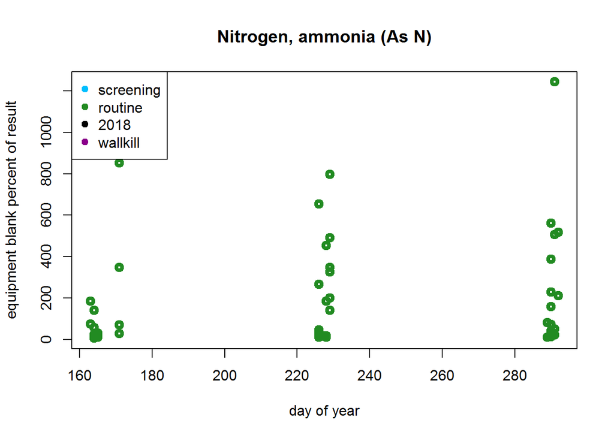

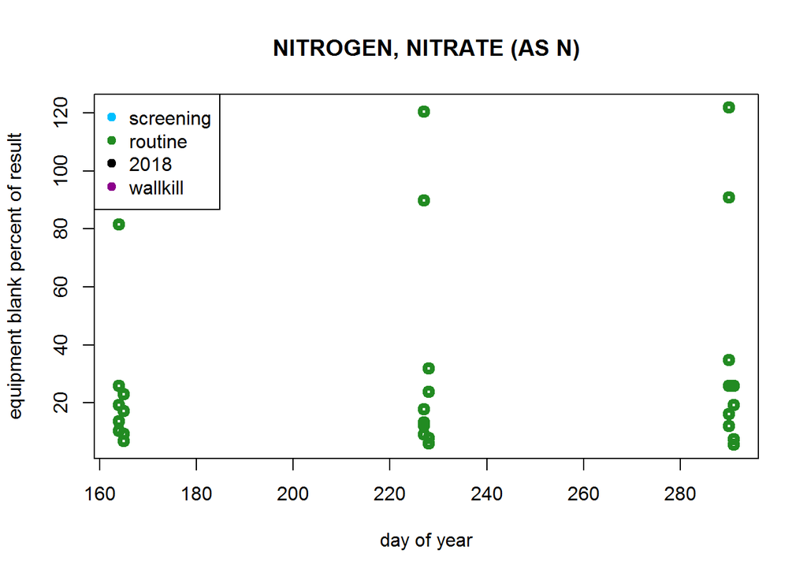

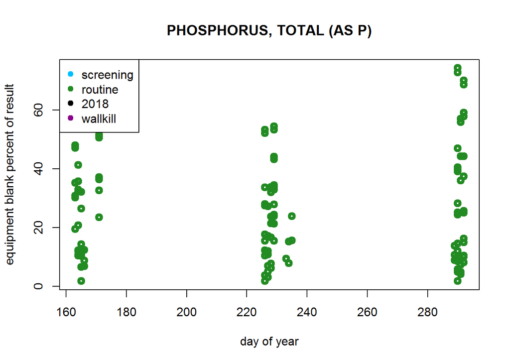

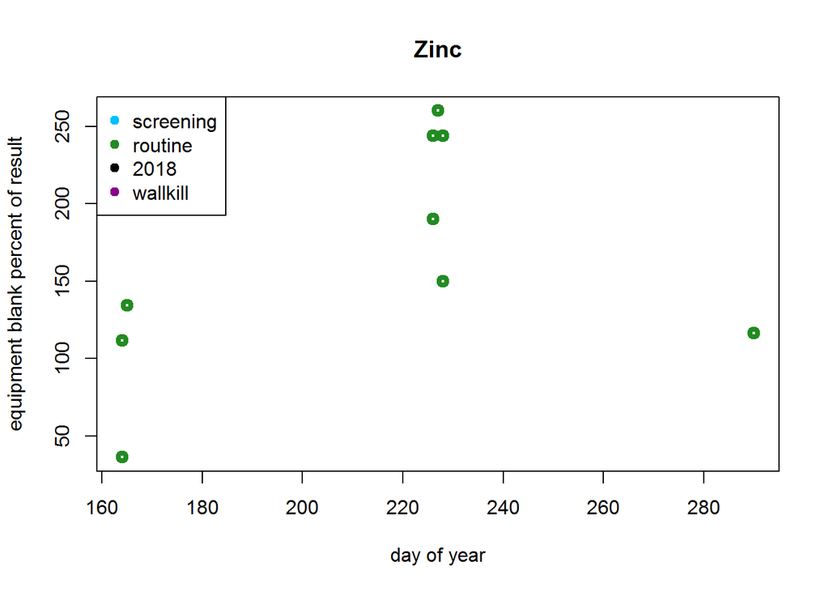

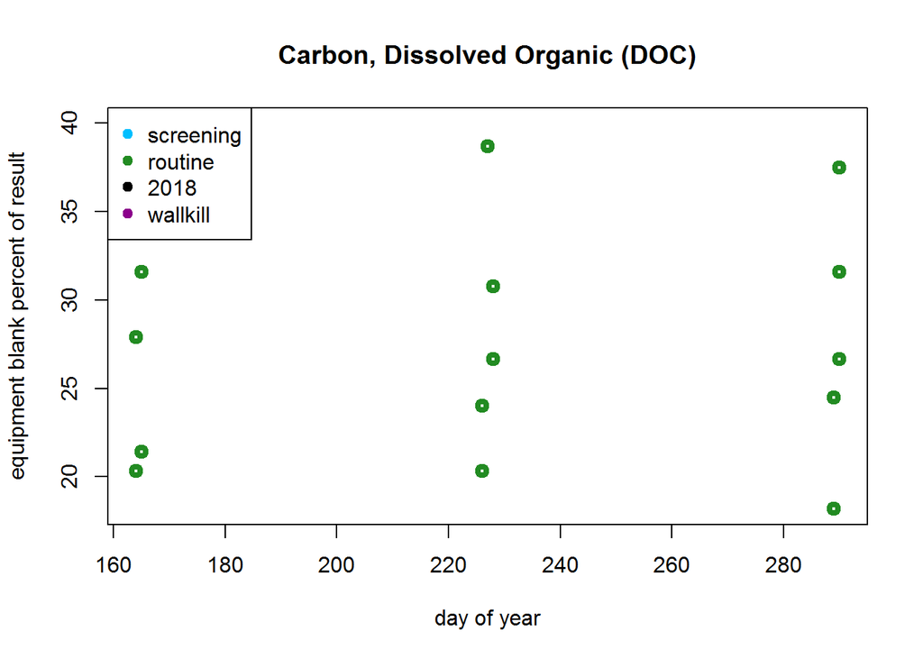

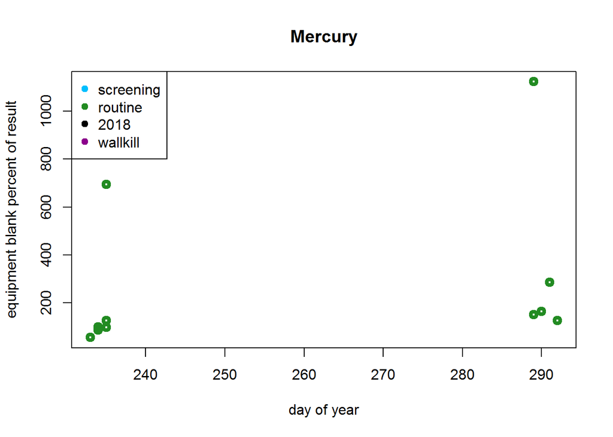

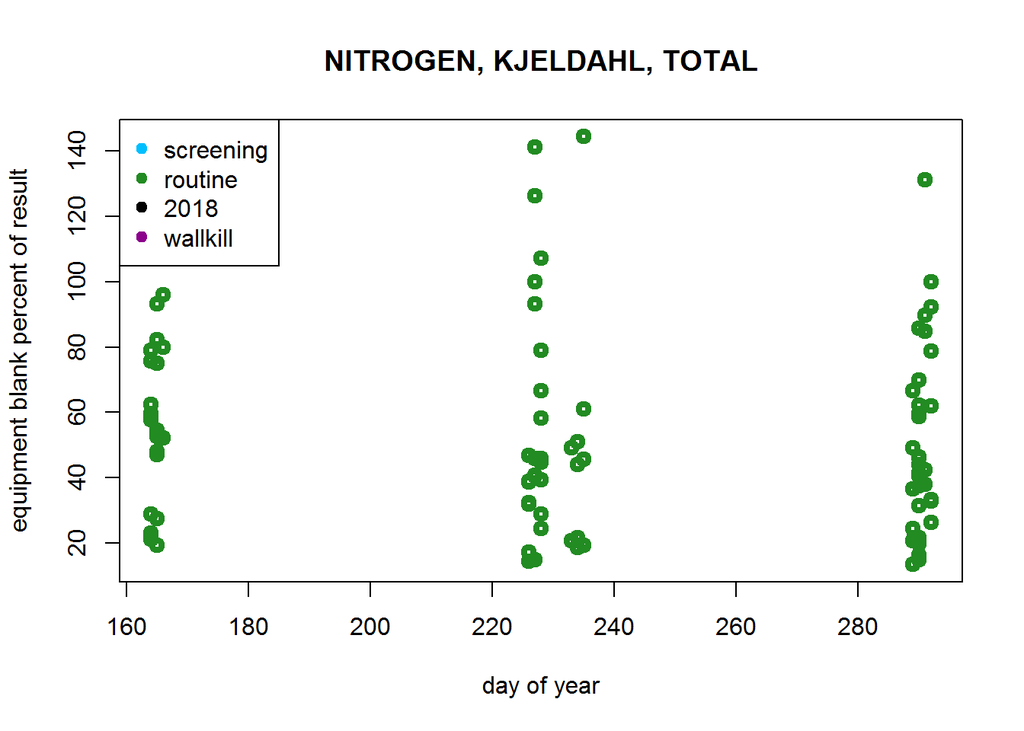

[2 more figures not shown]

##### Comparing EB to duplciates

My theory is that the duplicate samples measure the variance in sampling. Therefore, if there are EB within the variance observed in the duplicate sampling, then these EB hits should not be a concern.

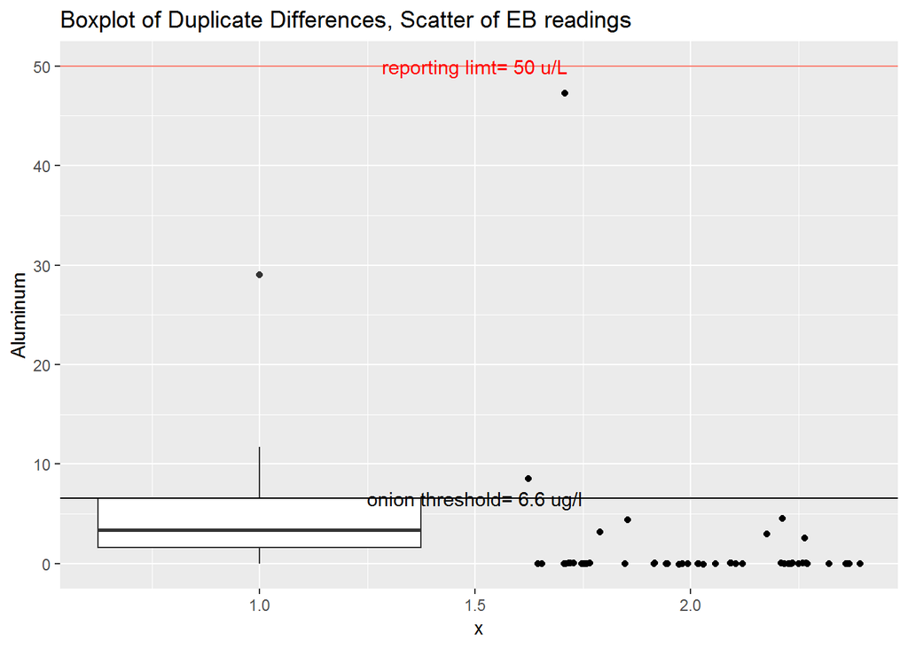

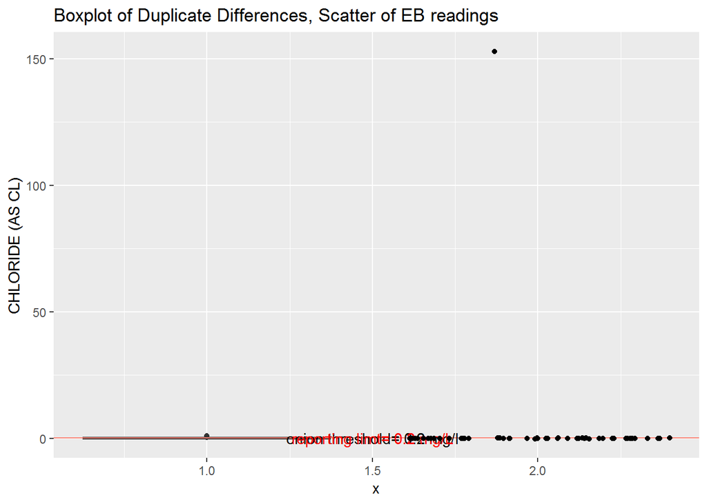

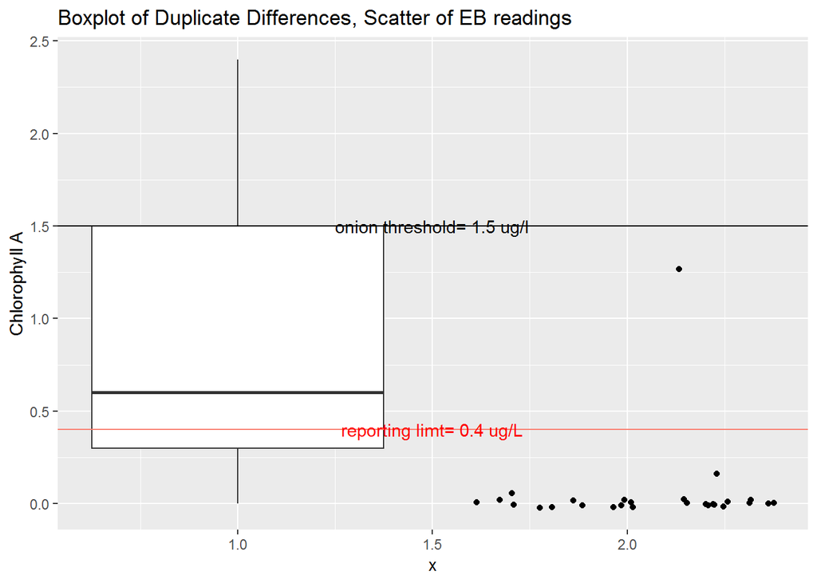

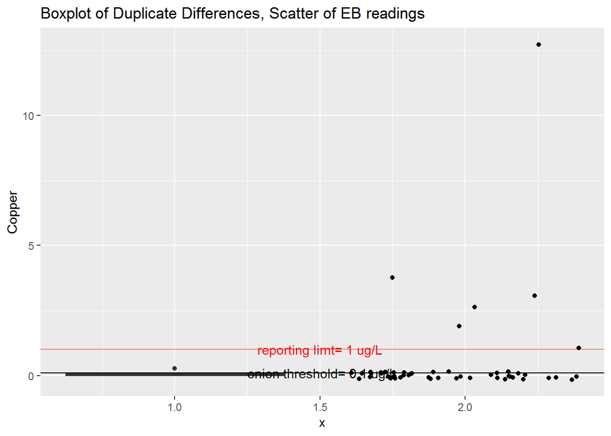

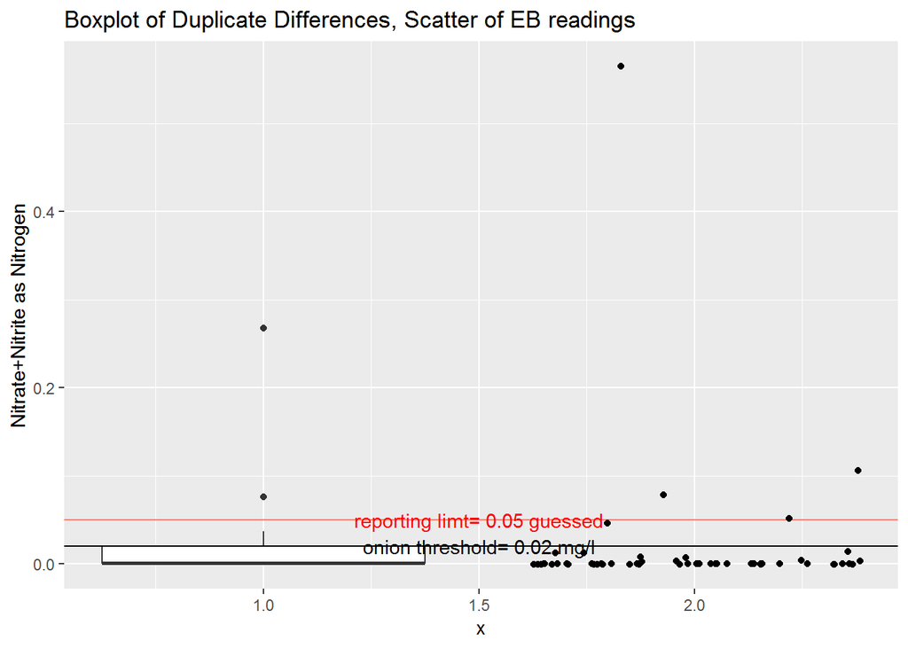